# Math 3B

Xiao Long

2026-01-19

```r
library(tidyverse)
```

```r
library(ggplot2)
library(dplyr)
library(readxl)
```

## Data Overview

The dataset contains student-level records from a full quarter of Math 3B usage.  
Each row corresponds to one student, and variables include exam grades, tutor usage, and performance metrics.

```r
df_raw <- read_excel("../data/FA25 Math 3B Data Full Quarter.xlsx", sheet = 1)
df_raw %>% glimpse()
```

```
## Rows: 280
## Columns: 12
## $ USERID                                   <dbl> 4437500, 4437521, 3972077, 44…
## $ `Pretest Grade`                          <chr> "0.01923076923", "0.038461538…
## $ `Midterm I Grade`                        <chr> "#VALUE!", "0.2", "0.56923076…
## $ `Midterm II Grade`                       <chr> "0.02702702703", "0.175675675…
## $ `Final Grade`                            <chr> "0", "0.1858974359", "0.39102…
## $ `Delta (pre to final)`                   <chr> "-0.01923076923", "0.14743589…
## $ `#of tutor requests`                     <chr> "0", "193", "7", "64", "24", …
## $ `# of questions correct`                 <dbl> 114, 131, 66, 219, 176, 170, …
## $ `# of questions incorrect`               <dbl> 130, 166, 58, 198, 84, 141, 2…
## $ `Total Questions Seen`                   <dbl> 129, 185, 100, 251, 181, 180,…
## $ Accuracy                                 <chr> "0.4672131148", "0.4410774411…
## $ `Number of Questions Right at First Try` <dbl> 2, 4, 17, 31, 0, 0, 7, 13, 21…
```

## Data Cleaning

Before analysis, I cleaned the dataset by converting relevant variables to numeric format and removing invalid entries caused by spreadsheet errors (e.g., “#VALUE!”, “#N/A”).

```r
bad_tokens <- c("#N/A", "#VALUE!", "#DIV/0!", "#ERROR!", "NA", "")

df <- df_raw %>%
  mutate(across(everything(), ~ as.character(.x))) %>%
  mutate(across(everything(), ~ ifelse(.x %in% bad_tokens, NA, .x))) %>%
  mutate(
    `Pretest Grade` = as.numeric(`Pretest Grade`),
    `Midterm I Grade` = as.numeric(`Midterm I Grade`),
    `Midterm II Grade` = as.numeric(`Midterm II Grade`),
    `Final Grade` = as.numeric(`Final Grade`),
    `Delta (pre to final)` = as.numeric(`Delta (pre to final)`),
    `#of tutor requests` = as.numeric(`#of tutor requests`),
    Accuracy = as.numeric(Accuracy)
  )
head(df)
```

```
## # A tibble: 6 × 12
##   USERID  `Pretest Grade` `Midterm I Grade` `Midterm II Grade` `Final Grade`
##   <chr>             <dbl>             <dbl>              <dbl>         <dbl>
## 1 4437500          0.0192            NA                 0.0270         0
## 2 4437521          0.0385             0.2               0.176          0.186
## 3 3972077          0.115              0.569             0.230          0.391
## 4 4437515          0.135              1                 0.730          0.763
## 5 4433828          0.192              0.492             0.405          0.327
## 6 4434040          0.192              0.508             0.568          0.423
## # ℹ 7 more variables: `Delta (pre to final)` <dbl>, `#of tutor requests` <dbl>,
## #   `# of questions correct` <chr>, `# of questions incorrect` <chr>,
## #   `Total Questions Seen` <chr>, Accuracy <dbl>,
## #   `Number of Questions Right at First Try` <chr>
```

## Learning Gain Validation

The dataset provides a pre-computed learning gain variable (`Delta (pre to final)`).  
To ensure its correctness, I independently calculated learning gain as the difference between Final Grade and Pretest Grade.

```r
df <- df %>%
  mutate(
    delta_calc = `Final Grade` - `Pretest Grade`,
    delta_diff = `Delta (pre to final)` - delta_calc
  )

summary(df$delta_diff)
```

```
##    Min. 1st Qu.  Median    Mean 3rd Qu.    Max.    NA's
##       0       0       0       0       0       0      22
```

## Defining Learning Improvement

In addition to modeling learning gains as a continuous outcome, I also created a binary variable indicating whether a student improved over the quarter.

```r
df_clean <- df %>%
  filter(
    !is.na(delta_calc),
    !is.na(Accuracy),
    !is.na(`#of tutor requests`),
    !is.na(`Pretest Grade`)
  )
nrow(df_clean)
```

```
## [1] 258
```

```r
df_clean
```

```
## # A tibble: 258 × 14
##    USERID  `Pretest Grade` `Midterm I Grade` `Midterm II Grade` `Final Grade`
##    <chr>             <dbl>             <dbl>              <dbl>         <dbl>
##  1 4437500          0.0192            NA                 0.0270         0
##  2 4437521          0.0385             0.2               0.176          0.186
##  3 3972077          0.115              0.569             0.230          0.391
##  4 4437515          0.135              1                 0.730          0.763
##  5 4433828          0.192              0.492             0.405          0.327
##  6 4434040          0.192              0.508             0.568          0.423
##  7 4433887          0.192              0.938             0.608          0.513
##  8 4434527          0.212              0.677             0.649          0.526
##  9 4433904          0.231              0.446             0.176          0
## 10 4437522          0.231              0.446             0.635          0.455
## # ℹ 248 more rows
## # ℹ 9 more variables: `Delta (pre to final)` <dbl>, `#of tutor requests` <dbl>,
## #   `# of questions correct` <chr>, `# of questions incorrect` <chr>,
## #   `Total Questions Seen` <chr>, Accuracy <dbl>,
## #   `Number of Questions Right at First Try` <chr>, delta_calc <dbl>,
## #   delta_diff <dbl>
```

## Tutor Usage by Learning Outcome

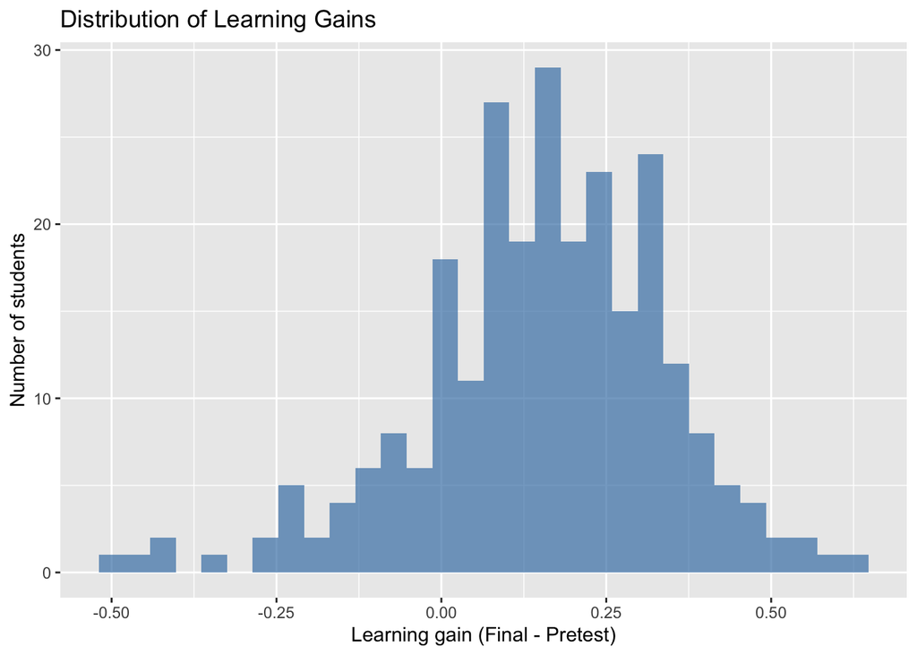

```r
ggplot(df_clean, aes(x = delta_calc)) +
  geom_histogram(bins = 30, fill = "steelblue", alpha = 0.7) +
  labs(
    title = "Distribution of Learning Gains",
    x = "Learning gain (Final - Pretest)",
    y = "Number of students"
  )
```

This histogram shows the distribution of learning gains (Final − Pretest), indicating that most students experienced positive improvement, with a small number showing negative gains.

## Linear Regression: Predicting the Magnitude of Learning Gains

```r
model <- lm(
  delta_calc ~ Accuracy + `#of tutor requests` + `Pretest Grade`,
  data = df_clean
)
summary(model)
```

```
##
## Call:
## lm(formula = delta_calc ~ Accuracy + `#of tutor requests` + `Pretest Grade`,
##     data = df_clean)
##
## Residuals:
##      Min       1Q   Median       3Q      Max
## -0.67104 -0.08575  0.01720  0.10641  0.38293
##
## Coefficients:
##                        Estimate Std. Error t value Pr(>|t|)
## (Intercept)           0.2677906  0.0782674   3.421 0.000726 ***
## Accuracy              0.2292424  0.1260490   1.819 0.070138 .
## `#of tutor requests`  0.0003230  0.0001331   2.427 0.015941 *
## `Pretest Grade`      -0.5063239  0.0697194  -7.262 4.65e-12 ***
## ---
## Signif. codes:  0 '***' 0.001 '**' 0.01 '*' 0.05 '.' 0.1 ' ' 1
##
## Residual standard error: 0.1683 on 254 degrees of freedom
## Multiple R-squared:  0.1901, Adjusted R-squared:  0.1806
## F-statistic: 19.88 on 3 and 254 DF,  p-value: 1.318e-11
```

To examine factors associated with the magnitude of learning gains, I first fit a linear regression model predicting continuous learning gain (Final Grade − Pretest Grade) from tutor accuracy, number of tutor requests, and pretest grade.

Overall, the model explains a modest proportion of variance in learning gains (Adjusted R² = 0.18/1.00), indicating that approximately 18% of the variance in learning gains is explained by the predictors. This indicates that while the predictors are statistically informative, a large portion of variability in student improvement remains unexplained by this linear specification.

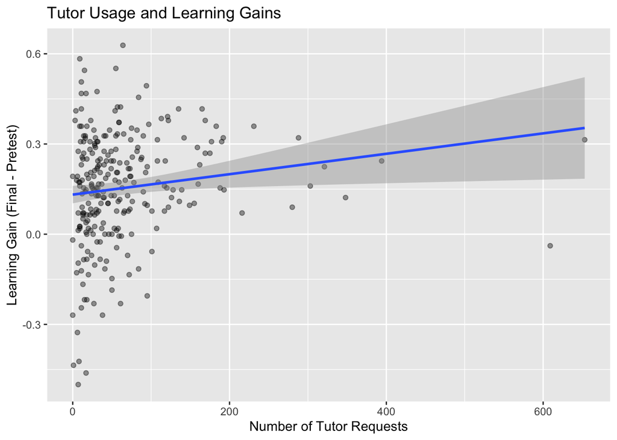

```r
ggplot(df_clean, aes(x = `#of tutor requests`, y = delta_calc)) +
  geom_point(alpha = 0.4) +
  geom_smooth(method = "lm") +
  labs(
    title = "Tutor Usage and Learning Gains",
    x = "Number of Tutor Requests",
    y = "Learning Gain (Final - Pretest)"
  )
```

This figure shows the relationship between tutor usage (number of tutor requests) and learning gains, measured as the difference between final and pretest grades.

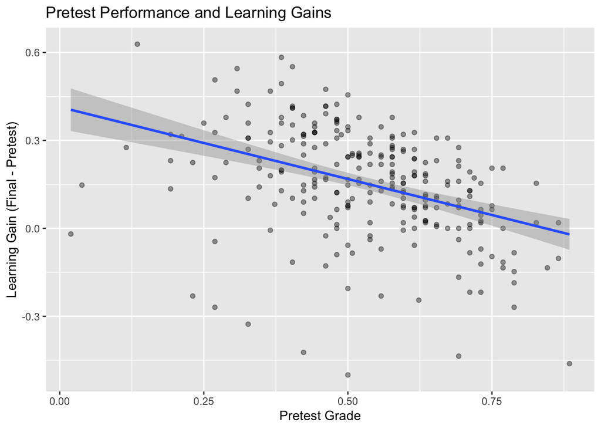

```r
ggplot(df_clean, aes(x = `Pretest Grade`, y = delta_calc)) +
  geom_point(alpha = 0.4) +
  geom_smooth(method = "lm") +
  labs(
    title = "Pretest Performance and Learning Gains",
    x = "Pretest Grade",
    y = "Learning Gain (Final - Pretest)"
  )
```

This figure shows the relationship between students’ pretest performance and their learning gains, defined as the difference between final and pretest grades.

## Logistic Regression: Modeling the Probability of Improvement

To complement the linear regression analysis of learning gains, I also construct a binary outcome variable indicating whether a student improved at all. Rather than predicting the magnitude of improvement, I next model the probability that a student improves at all using logistic regression.

```r
df_clean <- df_clean %>%
  mutate(
    improved = ifelse(delta_calc > 0, 1, 0)
  )
table(df_clean$improved)
```

```
##
##   0   1
##  46 212
```

Here I use logistic regression to model whether a student improved at all (1 = improved, 0 = no improvement), rather than modeling the size of learning gains.

```r
logit_model <- glm(
  improved ~ Accuracy + `#of tutor requests` + `Pretest Grade`,
  data = df_clean,
  family = binomial
)
summary(logit_model)
```

```
##
## Call:
## glm(formula = improved ~ Accuracy + `#of tutor requests` + `Pretest Grade`,
##     family = binomial, data = df_clean)
##
## Coefficients:
##                       Estimate Std. Error z value Pr(>|z|)
## (Intercept)           2.164638   1.259442   1.719  0.08566 .
## Accuracy              2.036356   1.893430   1.075  0.28216
## `#of tutor requests`  0.005398   0.003524   1.532  0.12560
## `Pretest Grade`      -3.807682   1.219238  -3.123  0.00179 **
## ---
## Signif. codes:  0 '***' 0.001 '**' 0.01 '*' 0.05 '.' 0.1 ' ' 1
##
## (Dispersion parameter for binomial family taken to be 1)
##
##     Null deviance: 241.90  on 257  degrees of freedom
## Residual deviance: 226.73  on 254  degrees of freedom
## AIC: 234.73
##
## Number of Fisher Scoring iterations: 5
```

This logistic regression models the probability that a student improves, given accuracy, number of tutor requests, and pretest grade.

Although tutor accuracy and the number of tutor requests have positive estimated coefficients, neither effect reaches conventional levels of statistical significance. This suggests that while higher accuracy and more frequent tutor use are associated with a higher probability of improvement, the evidence is not strong enough to rule out random variation in this sample.

In contrast, pretest grade shows a strong and statistically significant negative association with improvement, indicating that students who start with higher pretest scores are less likely to show additional gains.

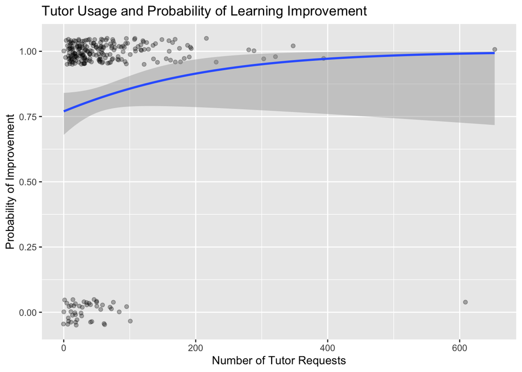

```r
ggplot(df_clean, aes(x = `#of tutor requests`, y = improved)) +
  geom_jitter(height = 0.05, alpha = 0.3) +
  geom_smooth(method = "glm", method.args = list(family = "binomial")) +
  labs(
    title = "Tutor Usage and Probability of Learning Improvement",
    x = "Number of Tutor Requests",
    y = "Probability of Improvement"
  )
```

This figure visualizes the relationship between the number of tutor requests and the probability that a student shows any learning improvement.

Each point represents a student, jittered vertically to reflect the binary outcome (0 = no improvement, 1 = improvement). The blue curve shows the fitted logistic regression line.

Overall, the plot suggests that increased tutor usage is associated with a higher chance of improvement, but the effect is noisy and varies widely across students. This indicates that tutor usage alone is not sufficient to reliably predict whether a student will improve.

## Binary Classification of Learning Improvement

To further analyze learning outcomes, I convert the continuous learning gain variable into a binary indicator of whether a student improved at all.

Specifically, students with a positive learning gain (Final − Pretest > 0) are labeled as **“Improved”**, while those with zero or negative gain are labeled as **“No Improvement”**. This allows me to compare tutor usage patterns between students who improved and those who did not.

```r
df_clean <- df_clean %>%
  mutate(
    improved = ifelse(delta_calc > 0, 1, 0),
    improved = factor(improved, levels = c(0, 1),
                      labels = c("No Improvement", "Improved"))
  )

table(df_clean$improved)
```

```
##
## No Improvement       Improved
##             46            212
```

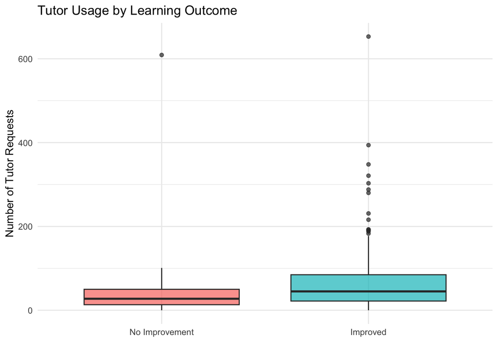

```r
ggplot(df_clean, aes(x = improved, y = `#of tutor requests`, fill = improved)) +
  geom_boxplot(alpha = 0.7) +
  labs(
    title = "Tutor Usage by Learning Outcome",
    x = "",
    y = "Number of Tutor Requests"
  ) +
  theme_minimal() +
  theme(legend.position = "none")
```

The boxplot above compares the distribution of tutor requests between students who improved and those who did not.

Overall, students who improved tend to have a higher median number of tutor requests, suggesting a positive association between tutor usage and learning improvement. However, there is substantial overlap between the two groups, indicating high variability in how students use the tutor.

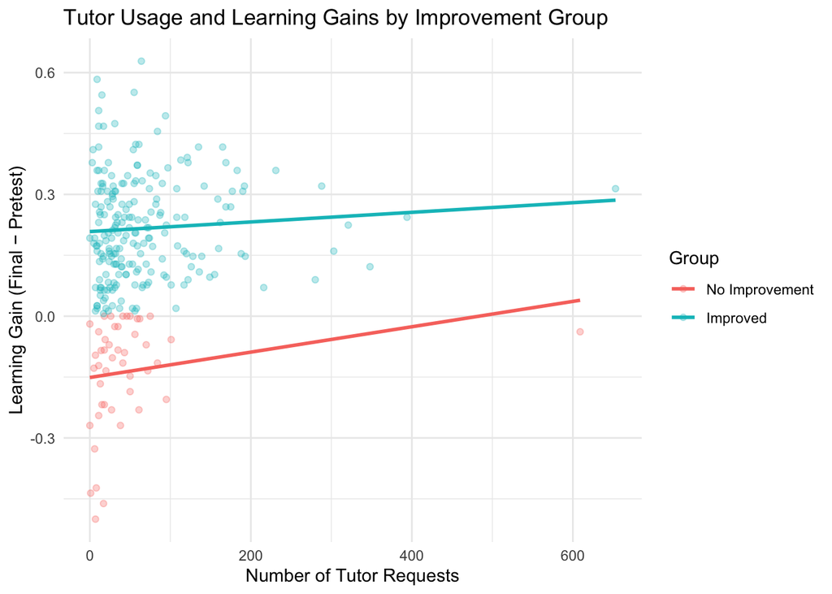

```r
ggplot(df_clean, aes(x = `#of tutor requests`, y = delta_calc, color = improved)) +
  geom_point(alpha = 0.3) +
  geom_smooth(method = "lm", se = FALSE) +
  labs(
    title = "Tutor Usage and Learning Gains by Improvement Group",
    x = "Number of Tutor Requests",
    y = "Learning Gain (Final − Pretest)",
    color = "Group"
  ) +
  theme_minimal()
```

This figure compares the relationship between tutor usage and learning gains separately for students who improved and those who did not.

For students who improved, learning gains tend to be positive across different levels of tutor usage, with a slight upward trend as the number of tutor requests increases. In contrast, students who did not improve generally exhibit negative learning gains, even as tutor usage increases.

This suggests that tutor usage alone does not guarantee improvement. Instead, students who are already improving may benefit more from additional tutor interactions, while increased tutor usage among non-improving students may reflect difficulty rather than effective learning.

```r
##Conclusion##
```

1. Learning gains show substantial variability across students. While most students experienced positive gains, a non-trivial subset showed little or no improvement, highlighting heterogeneity in learning outcomes.
2. Tutor usage is positively associated with learning gains, but the effect is modest. In the linear regression model, the number of tutor requests is positively related to learning gains, though the overall explanatory power of the model remains limited (Adjusted R² ≈ 0.18).
3. Tutor accuracy and tutor usage are positively correlated with improvement, but not always statistically significant. Although both variables show positive relationships with learning outcomes in visualizations and regression coefficients, their effects do not consistently reach statistical significance once pretest performance is controlled for.
4. Pretest performance is a strong predictor of learning outcomes. In both linear and logistic regression models, higher pretest grades are associated with smaller learning gains and a lower probability of improvement. This suggests a ceiling effect, where students who start at a higher level have less room to improve.
5. Binary outcome modeling reveals important differences across student groups. Logistic regression indicates that improvement is not solely driven by tutor usage or accuracy. Instead, students who improve appear to benefit more from tutor interactions, whereas higher tutor usage among non-improving students may reflect greater difficulty rather than effective learning.

Overall, these results suggest that while tutor interactions are associated with learning outcomes, student baseline performance plays a dominant role, and increased tutor usage alone does not guarantee improvement.